# Cardio Good Fitness Project

### Key analysis objectives of the Project

1. Explore the dataset to identify differences between customers of each product.
2. Explore relationships between the different attributes of customers.
3. Find new insights which could be relevant for the business.

### Data Context

The data is for customers of the treadmill product(s) of a retail store called Cardio Good Fitness. It contains the following variables

1. Product - the model no. of the treadmill
2. Age - in no of years, of the customer
3. Gender - of the customer
4. Education - in no. of years, of the customer
5. Marital Status - of the customer
6. Usage - Avg. # times the customer wants to use the treadmill every week
7. Fitness - Self rated fitness score of the customer (5 - very fit, 1 - very unfit)
8. Income - of the customer
9. Miles- expected to run

#### Importing all the required packages for the project:

```python
import pandas as pd #importing Pandas for dataset import
import matplotlib.pyplot as plt #importing for basic visualization and seaborn
import seaborn as sns #importing for better visualization features
import warnings # importing to suppress the warnings of deprecated features
warnings.filterwarnings('ignore') # suppress the warnings
#for inline plotting
%matplotlib inline
pd.set_option('display.float_format', lambda x: '%.5f' % x) #to suppress scientific notations
```

#### Read in the dataset in cardfit using pandas

```python
#importing dataset stored in csv file
cardfit = pd.read_csv(r'C:\Users\user\Desktop\AI_ML_Austin\notebook prog files\ProjectWork1\CardioGoodFitness.csv')
```

#### To assess the data set

```python
cardfit.head(10) #display top 10 rows
```

|  | Product | Age | Gender | Education | MaritalStatus | Usage | Fitness | Income | Miles |
| --- | --- | --- | --- | --- | --- | --- | --- | --- | --- |
| 0 | TM195 | 18 | Male | 14 | Single | 3 | 4 | 29562 | 112 |
| 1 | TM195 | 19 | Male | 15 | Single | 2 | 3 | 31836 | 75 |
| 2 | TM195 | 19 | Female | 14 | Partnered | 4 | 3 | 30699 | 66 |
| 3 | TM195 | 19 | Male | 12 | Single | 3 | 3 | 32973 | 85 |
| 4 | TM195 | 20 | Male | 13 | Partnered | 4 | 2 | 35247 | 47 |
| 5 | TM195 | 20 | Female | 14 | Partnered | 3 | 3 | 32973 | 66 |
| 6 | TM195 | 21 | Female | 14 | Partnered | 3 | 3 | 35247 | 75 |
| 7 | TM195 | 21 | Male | 13 | Single | 3 | 3 | 32973 | 85 |
| 8 | TM195 | 21 | Male | 15 | Single | 5 | 4 | 35247 | 141 |
| 9 | TM195 | 21 | Female | 15 | Partnered | 2 | 3 | 37521 | 85 |

The dataset looks clean and consistent with the description provided in the Data Dictionary.

#### Check the shape of the provided data

```python
cardfit.shape #diaply shape of data (rows and columns)
```

```
(180, 9)
```

There are 180 rows/observations of 9 columns

#### Check datatype count

```python
cardfit.dtypes.value_counts() #Gives count of the different datatype in dataset
```

```
int64     6
object    3
dtype: int64
```

#### Check the datatype of the variables to make sure that the data is read in properly

```python
cardfit.dtypes #display all datatypes
```

```
Product          object
Age               int64
Gender           object
Education         int64
MaritalStatus    object
Usage             int64
Fitness           int64
Income            int64
Miles             int64
dtype: object
```

1. There are 3 columns of object type (Product, Gender and Marital status)
2. All the other variables are numerical int64.

#### Get the complete info of the dataset

```python
cardfit.info() #display complete info
```

```
<class 'pandas.core.frame.DataFrame'>
RangeIndex: 180 entries, 0 to 179
Data columns (total 9 columns):
 #   Column         Non-Null Count  Dtype
---  ------         --------------  -----
 0   Product        180 non-null    object
 1   Age            180 non-null    int64
 2   Gender         180 non-null    object
 3   Education      180 non-null    int64
 4   MaritalStatus  180 non-null    object
 5   Usage          180 non-null    int64
 6   Fitness        180 non-null    int64
 7   Income         180 non-null    int64
 8   Miles          180 non-null    int64
dtypes: int64(6), object(3)
memory usage: 12.8+ KB
```

#### The description of data using

```python
cardfit.describe() #decription of data, display does not include object type
```

|  | Age | Education | Usage | Fitness | Income | Miles |
| --- | --- | --- | --- | --- | --- | --- |
| count | 180.00000 | 180.00000 | 180.00000 | 180.00000 | 180.00000 | 180.00000 |
| mean | 28.78889 | 15.57222 | 3.45556 | 3.31111 | 53719.57778 | 103.19444 |
| std | 6.94350 | 1.61705 | 1.08480 | 0.95887 | 16506.68423 | 51.86360 |
| min | 18.00000 | 12.00000 | 2.00000 | 1.00000 | 29562.00000 | 21.00000 |
| 25% | 24.00000 | 14.00000 | 3.00000 | 3.00000 | 44058.75000 | 66.00000 |
| 50% | 26.00000 | 16.00000 | 3.00000 | 3.00000 | 50596.50000 | 94.00000 |
| 75% | 33.00000 | 16.00000 | 4.00000 | 4.00000 | 58668.00000 | 114.75000 |
| max | 50.00000 | 21.00000 | 7.00000 | 5.00000 | 104581.00000 | 360.00000 |

Object type excluded in the result set only numerical data (int64) displayed

#### Describe all columns

```python
cardfit.describe(include="all") #describe all dataset
```

|  | Product | Age | Gender | Education | MaritalStatus | Usage | Fitness | Income | Miles |
| --- | --- | --- | --- | --- | --- | --- | --- | --- | --- |
| count | 180 | 180.00000 | 180 | 180.00000 | 180 | 180.00000 | 180.00000 | 180.00000 | 180.00000 |
| unique | 3 | nan | 2 | nan | 2 | nan | nan | nan | nan |
| top | TM195 | nan | Male | nan | Partnered | nan | nan | nan | nan |
| freq | 80 | nan | 104 | nan | 107 | nan | nan | nan | nan |
| mean | NaN | 28.78889 | NaN | 15.57222 | NaN | 3.45556 | 3.31111 | 53719.57778 | 103.19444 |
| std | NaN | 6.94350 | NaN | 1.61705 | NaN | 1.08480 | 0.95887 | 16506.68423 | 51.86360 |
| min | NaN | 18.00000 | NaN | 12.00000 | NaN | 2.00000 | 1.00000 | 29562.00000 | 21.00000 |
| 25% | NaN | 24.00000 | NaN | 14.00000 | NaN | 3.00000 | 3.00000 | 44058.75000 | 66.00000 |
| 50% | NaN | 26.00000 | NaN | 16.00000 | NaN | 3.00000 | 3.00000 | 50596.50000 | 94.00000 |
| 75% | NaN | 33.00000 | NaN | 16.00000 | NaN | 4.00000 | 4.00000 | 58668.00000 | 114.75000 |
| max | NaN | 50.00000 | NaN | 21.00000 | NaN | 7.00000 | 5.00000 | 104581.00000 | 360.00000 |

Customer Profile based on the data set:

1. Total number of customers are 180.
2. Total number of products used by the customers are 3.
3. TM195 is most used product (80 customers)
4. Mean age of customer is 28 years (Min 18 years and Max 50 years)
5. There are more male customers (104) than females (76)
6. Mean education of the customer is around 15 years.The range varies from 12 years to 21 years.
7. Customer usage ranges from 2 to 7 and mean usage value is 3.4
8. Mean fitness of customer in scale of 1 to 5 is 3.3
9. Income of customer ranges from approx 29.5K to 104.5k where avg income is approx 53.7k
10. Miles run by the customer ranges from 21 to 360. Mean usage in approx 103 miles.

#### Checking for missing values

```python
def missingvaluecheck(dat): #function to find missing values within the dataset
    calc_total = dat.isnull().sum().sort_values(ascending=False) #Checking for total null values
    calc_percent = (dat.isnull().sum()/dat.isnull().count()).sort_values(ascending=False) #checking percentage
    data_missing = pd.concat([calc_total, calc_percent], axis=1, keys=['Total', 'Percent']) #to display missing data count and percentage
    return data_missing # return the dataframe
missingvaluecheck(cardfit) #calling the function
```

|  | Total | Percent |
| --- | --- | --- |
| Miles | 0 | 0.00000 |
| Income | 0 | 0.00000 |
| Fitness | 0 | 0.00000 |
| Usage | 0 | 0.00000 |
| MaritalStatus | 0 | 0.00000 |
| Education | 0 | 0.00000 |
| Gender | 0 | 0.00000 |
| Age | 0 | 0.00000 |
| Product | 0 | 0.00000 |

#### No missing values found in the dataset

## Data Analysis: Univariate Analysis

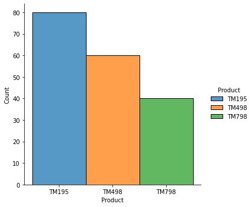

```python
sns.displot(cardfit, x="Product", hue="Product", multiple="stack"); #use of stack for Product
```

Most used product is TM195 and least used is TM798.

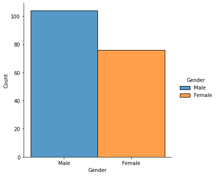

```python
sns.displot(cardfit, x="Gender", hue="Gender", multiple="stack"); #use of stack for Gender
```

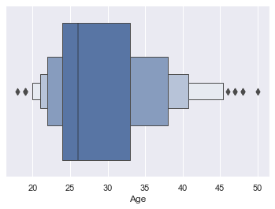

```python
sns.set(color_codes=True) #sets the colour codes for seaborn display
sns.boxenplot(x=cardfit["Age"]); #using  box-and-whisker plot
```

Mean age of customer in dataset is around 28. Most of the customers are fairly young. The customers less than 24 and more than 33 are fairly few in numbers. There are some out outliers beyond 46 years

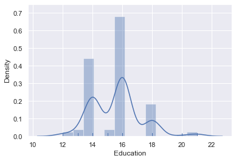

```python
sns.distplot(cardfit['Education'], rug=True); #using distplot to display the kde-default true and rug
```

Average education of the customer is arround 16 years

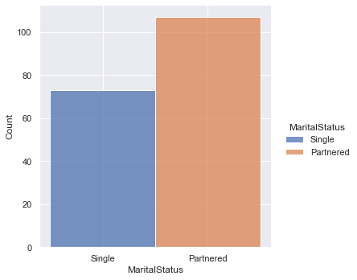

```python
sns.displot(cardfit, x="MaritalStatus", hue="MaritalStatus", multiple="stack"); #use of stack for Marital Status
```

More customers are Partnered than Singles

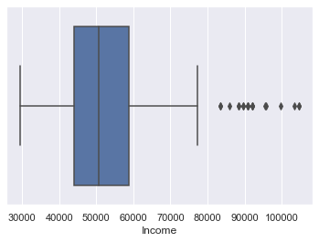

```python
sns.boxplot(x=cardfit["Income"]); #using  box-and-whisker plot
```

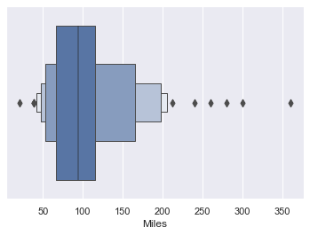

```python
sns.boxenplot(x=cardfit["Miles"]); #using  box-and-whisker plot
```

Most of the customers run between 50 to 200 Miles. There very few outlier who run less than 40 miles and more than 210 Miles.

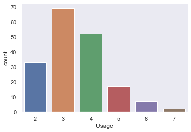

```python
sns.countplot(cardfit['Usage']); #to find out fitness count
```

For most of the customers moderate level of usage (3-4) is more prominent

## Data Analysis: Bivariate Analysis

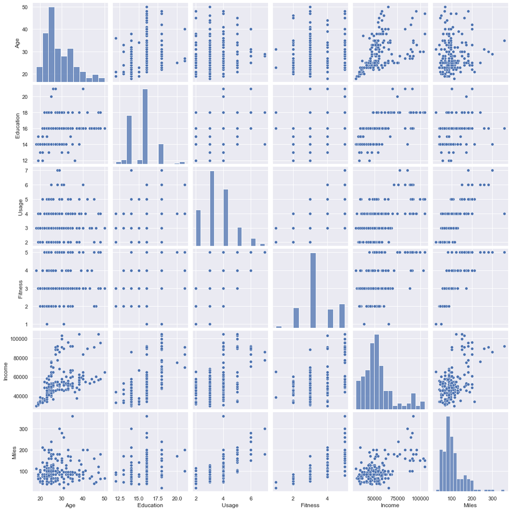

```python
sns.pairplot(cardfit); #pair plot multiple pair wise bivariate distributions
```

The pair plot between the values in dataset show the overall distibution against each of the int columns. This give an overall view aginst the selected dataset values.

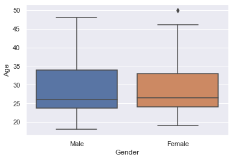

```python
sns.boxplot(x="Gender", y="Age", data=cardfit); #box plot
```

The target age group that can result into more sales 23 to 33 (Main users of the products)

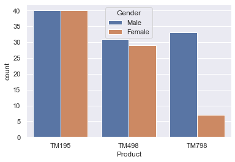

```python
sns.countplot(x="Product", hue="Gender", data=cardfit); #count plot
```

TM789 is not popular with Females

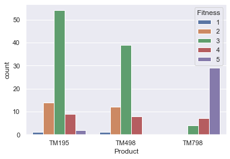

```python
sns.countplot(x="Product", hue="Fitness", data=cardfit); #using count plot for product and fitness
```

Most fit people are using TM798, people with average fitness prefer TM195 and TM498

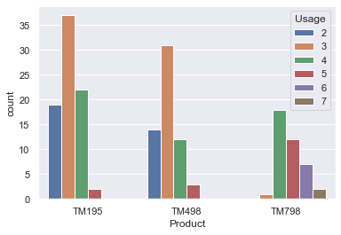

```python
sns.countplot(x="Product", hue="Usage", data=cardfit); #use of count plot for product and usage
```

Most used product is TM195

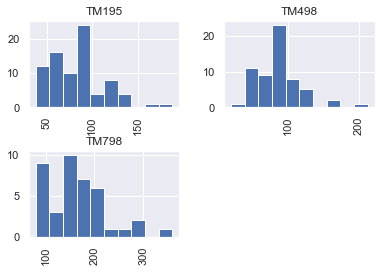

```python
cardfit.hist(by='Product',column = 'Miles'); # using histogram for each product and miles
```

People using TM798 run more number of miles

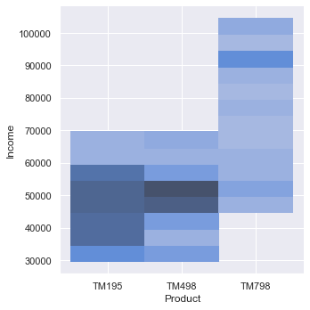

```python
sns.displot(cardfit, x="Product", y="Income"); #use of displot
```

TM195 and TM498 are popular with customers having income 30K to 70K. TM798 is more popular with customer of income group 70K and above

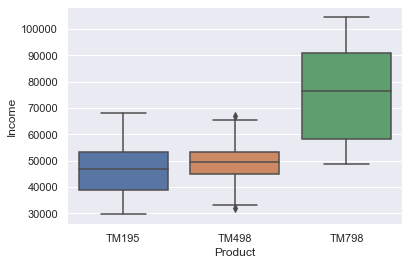

```python
sns.boxplot(cardfit['Product'], cardfit['Income']); #use of boxplot
```

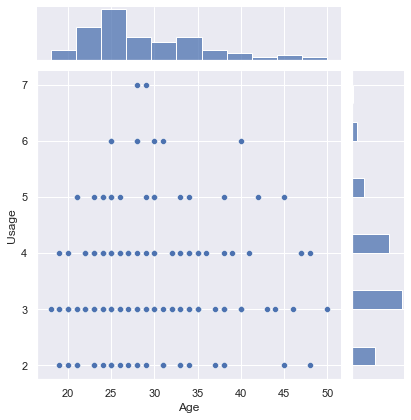

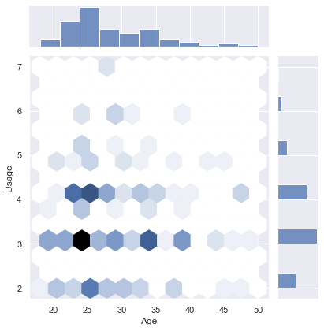

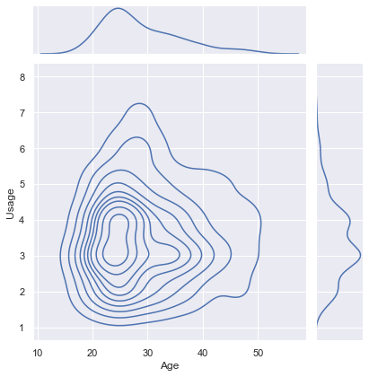

```python
#Three different ways to represent joint plot (Age vs Usage)
sns.jointplot(cardfit['Age'], cardfit['Usage']);
sns.jointplot(cardfit['Age'], cardfit['Usage'], kind="hex");
sns.jointplot(cardfit['Age'], cardfit['Usage'], kind="kde");
```

Use of disjoint plot in three different ways to represent the concentration.

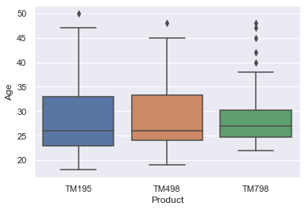

```python
sns.boxplot(cardfit['Product'], cardfit['Age']); #use of boxplot
```

Usage of the products are more concentrated around age group 22 to 33

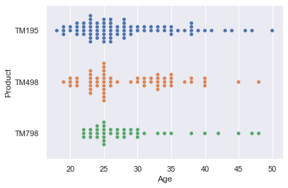

```python
sns.swarmplot(cardfit['Age'], cardfit['Product']); #use of swarmplot
```

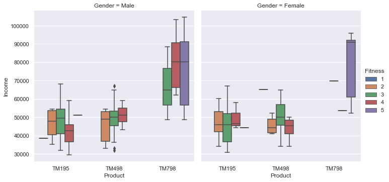

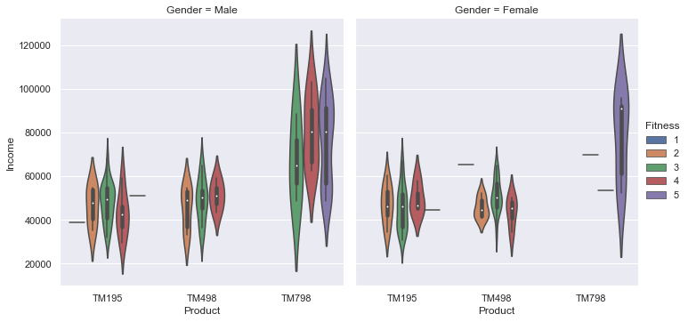

```python
#use of catplot - Type Box
sns.catplot(x="Product", y="Income", hue="Fitness", col="Gender", data=cardfit, kind="box");
sns.catplot(x="Product", y="Income", hue="Fitness", col="Gender", data=cardfit, kind="violin"); #use of catplot - Type Violin
```

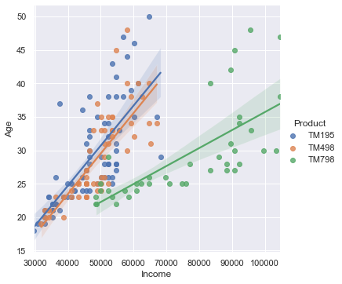

```python
sns.lmplot(x="Income", y="Age", data=cardfit, hue="Product"); #use of Implot
```

Above three plots clearly establishes the TM798 is clearly used by seprate set of customer considering the age and income

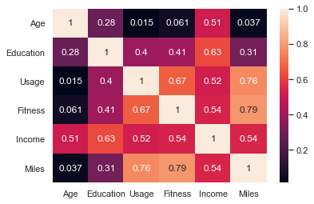

```python
corr = cardfit.corr()
sns.heatmap(corr, annot=True); # using heat map
```